# R Notebook

**Importing The Libraries**

```r
library(car)

library(e1071)
library(glmnet)
library(stats)
library(utils)
library(datasets)
library(ggplot2)
library(polynom)
```

**UNDERSTANDING THE DATA**

```r
# Reading The Data set and creating copies for the Data sets
df  = read.csv('Life Expectancy Data.csv')

df_copy = data.frame(df)
df_copy_1 = subset(df, select = -c(Country,Year,Status))
```

**To view the Data set**

```r
head(df)
```

|  | Country | Year | Status | Life.expectancy | Adult.Mortality | infant.deaths | Alcohol | percentage.expenditure | Hepatitis.B | Measles | BMI | under.five.deaths | Polio | Total.expenditure | Diphtheria | HIV.AIDS | GDP | Population | thinness..1.19.years | thinness.5.9.years | Income.composition.of.resources | Schooling |
| --- | --- | --- | --- | --- | --- | --- | --- | --- | --- | --- | --- | --- | --- | --- | --- | --- | --- | --- | --- | --- | --- | --- |
| 1 | Afghanistan | 2015 | Developing | 65.0 | 263 | 62 | 0.01 | 71.279624 | 65 | 1154 | 19.1 | 83 | 6 | 8.16 | 65 | 0.1 | 584.25921 | 33736494 | 17.2 | 17.3 | 0.479 | 10.1 |
| 2 | Afghanistan | 2014 | Developing | 59.9 | 271 | 64 | 0.01 | 73.523582 | 62 | 492 | 18.6 | 86 | 58 | 8.18 | 62 | 0.1 | 612.69651 | 327582 | 17.5 | 17.5 | 0.476 | 10.0 |
| 3 | Afghanistan | 2013 | Developing | 59.9 | 268 | 66 | 0.01 | 73.219243 | 64 | 430 | 18.1 | 89 | 62 | 8.13 | 64 | 0.1 | 631.74498 | 31731688 | 17.7 | 17.7 | 0.470 | 9.9 |
| 4 | Afghanistan | 2012 | Developing | 59.5 | 272 | 69 | 0.01 | 78.184215 | 67 | 2787 | 17.6 | 93 | 67 | 8.52 | 67 | 0.1 | 669.95900 | 3696958 | 17.9 | 18.0 | 0.463 | 9.8 |
| 5 | Afghanistan | 2011 | Developing | 59.2 | 275 | 71 | 0.01 | 7.097109 | 68 | 3013 | 17.2 | 97 | 68 | 7.87 | 68 | 0.1 | 63.53723 | 2978599 | 18.2 | 18.2 | 0.454 | 9.5 |
| 6 | Afghanistan | 2010 | Developing | 58.8 | 279 | 74 | 0.01 | 79.679367 | 66 | 1989 | 16.7 | 102 | 66 | 9.20 | 66 | 0.1 | 553.32894 | 2883167 | 18.4 | 18.4 | 0.448 | 9.2 |

**Dimensions of the Data set**

```r
dim(df)
```

```
[1] 2938   22
```

**The Type of Data set**

```r
str(df)
```

```
'data.frame':   2938 obs. of  22 variables:
 $ Country                        : chr  "Afghanistan" "Afghanistan" "Afghanistan" "Afghanistan" ...
 $ Year                           : int  2015 2014 2013 2012 2011 2010 2009 2008 2007 2006 ...
 $ Status                         : chr  "Developing" "Developing" "Developing" "Developing" ...
 $ Life.expectancy                : num  65 59.9 59.9 59.5 59.2 58.8 58.6 58.1 57.5 57.3 ...
 $ Adult.Mortality                : int  263 271 268 272 275 279 281 287 295 295 ...
 $ infant.deaths                  : int  62 64 66 69 71 74 77 80 82 84 ...
 $ Alcohol                        : num  0.01 0.01 0.01 0.01 0.01 0.01 0.01 0.03 0.02 0.03 ...
 $ percentage.expenditure         : num  71.3 73.5 73.2 78.2 7.1 ...
 $ Hepatitis.B                    : int  65 62 64 67 68 66 63 64 63 64 ...
 $ Measles                        : int  1154 492 430 2787 3013 1989 2861 1599 1141 1990 ...
 $ BMI                            : num  19.1 18.6 18.1 17.6 17.2 16.7 16.2 15.7 15.2 14.7 ...
 $ under.five.deaths              : int  83 86 89 93 97 102 106 110 113 116 ...
 $ Polio                          : int  6 58 62 67 68 66 63 64 63 58 ...
 $ Total.expenditure              : num  8.16 8.18 8.13 8.52 7.87 9.2 9.42 8.33 6.73 7.43 ...
 $ Diphtheria                     : int  65 62 64 67 68 66 63 64 63 58 ...
 $ HIV.AIDS                       : num  0.1 0.1 0.1 0.1 0.1 0.1 0.1 0.1 0.1 0.1 ...
 $ GDP                            : num  584.3 612.7 631.7 670 63.5 ...
 $ Population                     : num  33736494 327582 31731688 3696958 2978599 ...
 $ thinness..1.19.years           : num  17.2 17.5 17.7 17.9 18.2 18.4 18.6 18.8 19 19.2 ...
 $ thinness.5.9.years             : num  17.3 17.5 17.7 18 18.2 18.4 18.7 18.9 19.1 19.3 ...
 $ Income.composition.of.resources: num  0.479 0.476 0.47 0.463 0.454 0.448 0.434 0.433 0.415 0.405 ...
 $ Schooling                      : num  10.1 10 9.9 9.8 9.5 9.2 8.9 8.7 8.4 8.1 ...
```

**Details of the Data set**

```r
summary(df)
```

```
   Country               Year         Status          Life.expectancy Adult.Mortality infant.deaths
 Length:2938        Min.   :2000   Length:2938        Min.   :36.30   Min.   :  1.0   Min.   :   0.0
 Class :character   1st Qu.:2004   Class :character   1st Qu.:63.10   1st Qu.: 74.0   1st Qu.:   0.0
 Mode  :character   Median :2008   Mode  :character   Median :72.10   Median :144.0   Median :   3.0
                    Mean   :2008                      Mean   :69.22   Mean   :164.8   Mean   :  30.3
                    3rd Qu.:2012                      3rd Qu.:75.70   3rd Qu.:228.0   3rd Qu.:  22.0
                    Max.   :2015                      Max.   :89.00   Max.   :723.0   Max.   :1800.0
                                                      NA's   :10      NA's   :10
    Alcohol        percentage.expenditure  Hepatitis.B       Measles              BMI
 Min.   : 0.0100   Min.   :    0.000      Min.   : 1.00   Min.   :     0.0   Min.   : 1.00
 1st Qu.: 0.8775   1st Qu.:    4.685      1st Qu.:77.00   1st Qu.:     0.0   1st Qu.:19.30
 Median : 3.7550   Median :   64.913      Median :92.00   Median :    17.0   Median :43.50
 Mean   : 4.6029   Mean   :  738.251      Mean   :80.94   Mean   :  2419.6   Mean   :38.32
 3rd Qu.: 7.7025   3rd Qu.:  441.534      3rd Qu.:97.00   3rd Qu.:   360.2   3rd Qu.:56.20
 Max.   :17.8700   Max.   :19479.912      Max.   :99.00   Max.   :212183.0   Max.   :87.30
 NA's   :194                              NA's   :553                        NA's   :34
 under.five.deaths     Polio       Total.expenditure   Diphtheria       HIV.AIDS           GDP
 Min.   :   0.00   Min.   : 3.00   Min.   : 0.370    Min.   : 2.00   Min.   : 0.100   Min.   :     1.68
 1st Qu.:   0.00   1st Qu.:78.00   1st Qu.: 4.260    1st Qu.:78.00   1st Qu.: 0.100   1st Qu.:   463.94
 Median :   4.00   Median :93.00   Median : 5.755    Median :93.00   Median : 0.100   Median :  1766.95
 Mean   :  42.04   Mean   :82.55   Mean   : 5.938    Mean   :82.32   Mean   : 1.742   Mean   :  7483.16
 3rd Qu.:  28.00   3rd Qu.:97.00   3rd Qu.: 7.492    3rd Qu.:97.00   3rd Qu.: 0.800   3rd Qu.:  5910.81
 Max.   :2500.00   Max.   :99.00   Max.   :17.600    Max.   :99.00   Max.   :50.600   Max.   :119172.74
                   NA's   :19      NA's   :226       NA's   :19                       NA's   :448
   Population        thinness..1.19.years thinness.5.9.years Income.composition.of.resources
 Min.   :3.400e+01   Min.   : 0.10        Min.   : 0.10      Min.   :0.0000
 1st Qu.:1.958e+05   1st Qu.: 1.60        1st Qu.: 1.50      1st Qu.:0.4930
 Median :1.387e+06   Median : 3.30        Median : 3.30      Median :0.6770
 Mean   :1.275e+07   Mean   : 4.84        Mean   : 4.87      Mean   :0.6276
 3rd Qu.:7.420e+06   3rd Qu.: 7.20        3rd Qu.: 7.20      3rd Qu.:0.7790
 Max.   :1.294e+09   Max.   :27.70        Max.   :28.60      Max.   :0.9480
 NA's   :652         NA's   :34           NA's   :34         NA's   :167
   Schooling
 Min.   : 0.00
 1st Qu.:10.10
 Median :12.30
 Mean   :11.99
 3rd Qu.:14.30
 Max.   :20.70
 NA's   :163
```

**Names of the Columns of the Dataset**

```r
colnames(df)
```

```
 [1] "Country"                         "Year"                            "Status"
 [4] "Life.expectancy"                 "Adult.Mortality"                 "infant.deaths"
 [7] "Alcohol"                         "percentage.expenditure"          "Hepatitis.B"
[10] "Measles"                         "BMI"                             "under.five.deaths"
[13] "Polio"                           "Total.expenditure"               "Diphtheria"
[16] "HIV.AIDS"                        "GDP"                             "Population"
[19] "thinness..1.19.years"            "thinness.5.9.years"              "Income.composition.of.resources"
[22] "Schooling"
```

**Missing Values and Handling**

```r
# Finding Out the No of Missing Values in the Datset

miss_val = sum(is.na(df))
print(paste0(" The Percentage of missing values in each Data set :   ",miss_val))
```

[output not shown]

**Graphs Of the Missing Values**

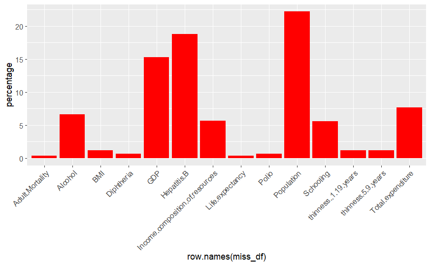

```r
feature <- c()
percentage <- c()
for (i in colnames(df)) {
  miss_per <- (sum(is.na(df[[i]]))/length(df[[i]]))*100
  if (miss_per > 0) {
    feature <- c(feature, i)
    percentage <- c(percentage, miss_per)
  }
}

miss_df <- data.frame(percentage, row.names=feature)
library(ggplot2)
ggplot(miss_df, aes(x=row.names(miss_df), y=percentage)) +
  geom_bar(stat="identity", fill="red") +
  theme(axis.text.x = element_text(angle = 45, hjust = 1))
```

**Find Out the Duplicate values**

```r
df[duplicated(df),]
```

| Country | Year | Status | Life.expectancy | Adult.Mortality | infant.deaths | Alcohol | percentage.expenditure | Hepatitis.B | Measles | BMI | under.five.deaths | Polio | Total.expenditure | Diphtheria | HIV.AIDS | GDP | Population | thinness..1.19.years | thinness.5.9.years | Income.composition.of.resources | Schooling |
| --- | --- | --- | --- | --- | --- | --- | --- | --- | --- | --- | --- | --- | --- | --- | --- | --- | --- | --- | --- | --- | --- |

```r
NA
NA
```

**Line Plot Between year and Life Expectancy**

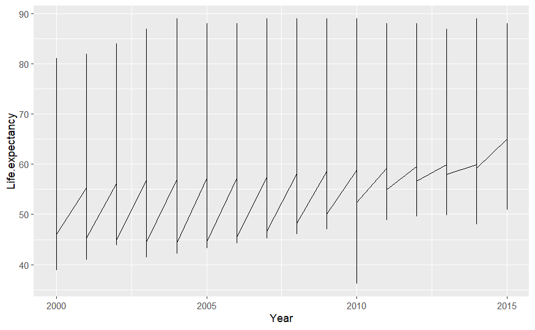

```r
library(ggplot2)

ggplot(df, aes(x = `Year`, y = `Life.expectancy`)) +
  geom_line()
```

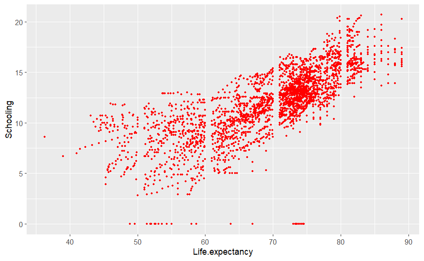

```r
library(ggplot2)


ggplot(df, aes(x = `Life.expectancy`, y = Schooling)) +
  geom_point(color='red',size =0.9)
```

```r
NA
NA
NA
```

**Filling The Missing values using Mean**

```r
df[, sapply(df, is.numeric)] <- apply(df[, sapply(df, is.numeric)], 2, function(x) replace(x, is.na(x), mean(x, na.rm = TRUE)))

df
```

| Country | Year | Status | Life.expectancy | Adult.Mortality | infant.deaths | Alcohol | percentage.expenditure | Hepatitis.B | Measles | BMI | under.five.deaths | Polio | Total.expenditure | Diphtheria | HIV.AIDS | GDP | Population | thinness..1.19.years | thinness.5.9.years | Income.composition.of.resources | Schooling |
| --- | --- | --- | --- | --- | --- | --- | --- | --- | --- | --- | --- | --- | --- | --- | --- | --- | --- | --- | --- | --- | --- |
| Afghanistan | 2015 | Developing | 65.00000 | 263.0000 | 62 | 0.010000 | 7.127962e+01 | 65.00000 | 1154 | 19.1 | 83 | 6 | 8.16000 | 65 | 0.1 | 584.259210 | 33736494 | 17.2 | 17.3 | 0.4790000 | 10.10000 |
| Afghanistan | 2014 | Developing | 59.90000 | 271.0000 | 64 | 0.010000 | 7.352358e+01 | 62.00000 | 492 | 18.6 | 86 | 58 | 8.18000 | 62 | 0.1 | 612.696514 | 327582 | 17.5 | 17.5 | 0.4760000 | 10.00000 |
| Afghanistan | 2013 | Developing | 59.90000 | 268.0000 | 66 | 0.010000 | 7.321924e+01 | 64.00000 | 430 | 18.1 | 89 | 62 | 8.13000 | 64 | 0.1 | 631.744976 | 31731688 | 17.7 | 17.7 | 0.4700000 | 9.90000 |
| Afghanistan | 2012 | Developing | 59.50000 | 272.0000 | 69 | 0.010000 | 7.818422e+01 | 67.00000 | 2787 | 17.6 | 93 | 67 | 8.52000 | 67 | 0.1 | 669.959000 | 3696958 | 17.9 | 18.0 | 0.4630000 | 9.80000 |
| Afghanistan | 2011 | Developing | 59.20000 | 275.0000 | 71 | 0.010000 | 7.097109e+00 | 68.00000 | 3013 | 17.2 | 97 | 68 | 7.87000 | 68 | 0.1 | 63.537231 | 2978599 | 18.2 | 18.2 | 0.4540000 | 9.50000 |
| Afghanistan | 2010 | Developing | 58.80000 | 279.0000 | 74 | 0.010000 | 7.967937e+01 | 66.00000 | 1989 | 16.7 | 102 | 66 | 9.20000 | 66 | 0.1 | 553.328940 | 2883167 | 18.4 | 18.4 | 0.4480000 | 9.20000 |
| Afghanistan | 2009 | Developing | 58.60000 | 281.0000 | 77 | 0.010000 | 5.676222e+01 | 63.00000 | 2861 | 16.2 | 106 | 63 | 9.42000 | 63 | 0.1 | 445.893298 | 284331 | 18.6 | 18.7 | 0.4340000 | 8.90000 |
| Afghanistan | 2008 | Developing | 58.10000 | 287.0000 | 80 | 0.030000 | 2.587393e+01 | 64.00000 | 1599 | 15.7 | 110 | 64 | 8.33000 | 64 | 0.1 | 373.361116 | 2729431 | 18.8 | 18.9 | 0.4330000 | 8.70000 |
| Afghanistan | 2007 | Developing | 57.50000 | 295.0000 | 82 | 0.020000 | 1.091016e+01 | 63.00000 | 1141 | 15.2 | 113 | 63 | 6.73000 | 63 | 0.1 | 369.835796 | 26616792 | 19.0 | 19.1 | 0.4150000 | 8.40000 |
| Afghanistan | 2006 | Developing | 57.30000 | 295.0000 | 84 | 0.030000 | 1.717152e+01 | 64.00000 | 1990 | 14.7 | 116 | 58 | 7.43000 | 58 | 0.1 | 272.563770 | 2589345 | 19.2 | 19.3 | 0.4050000 | 8.10000 |

[output cut: 990 more lines]

```r
sum(is.null(df))
```

```
[1] 0
```

**Pair Plots**

```r
#for (i in 1:ncol(df)) {
  #for (j in 1:ncol(df)) {
    #if (i != j) {
      #plot(df[,i], df[,j], main = paste(colnames(df)[i], " vs ", colnames(df)[j]))
    #}
  #}
#}
```

# Correalation Matrix and Heat Map :

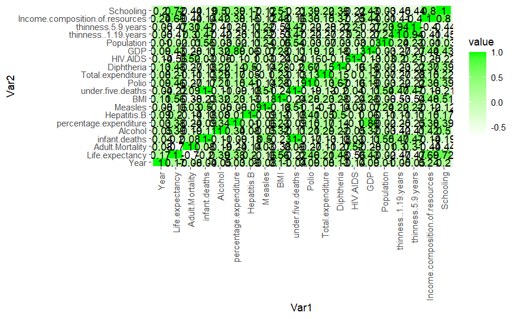

```r
# Create correlation matrix
library(reshape2)
df <- df[, sapply(df, is.numeric)]
corr <- cor(df)

# Melt correlation matrix
corr_melted <- melt(corr)

# Create heatmap
ggplot(corr_melted, aes(x=Var1, y=Var2)) +
  geom_tile(aes(fill=value)) +
  scale_fill_gradient(low="white", high="green") +
  geom_text(aes(label=round(value, 2)), color="black") +
  theme(axis.text.x = element_text(angle = 90, vjust = 0.5, hjust=1))
```

```r
sum(is.na(df))
```

```
[1] 0
```

```r
sum(is.na(df_copy))
```

```
[1] 2563
```

**Filling The Missing Values With Median Values :**

```r
df_copy[, sapply(df_copy, is.numeric)] <- apply(df_copy[, sapply(df_copy, is.numeric)], 2, function(x) replace(x, is.na(x), median(x, na.rm = TRUE)))

df_copy
```

| Country | Year | Status | Life.expectancy | Adult.Mortality | infant.deaths | Alcohol | percentage.expenditure | Hepatitis.B | Measles | BMI | under.five.deaths | Polio | Total.expenditure | Diphtheria | HIV.AIDS | GDP | Population | thinness..1.19.years | thinness.5.9.years | Income.composition.of.resources | Schooling |
| --- | --- | --- | --- | --- | --- | --- | --- | --- | --- | --- | --- | --- | --- | --- | --- | --- | --- | --- | --- | --- | --- |
| Afghanistan | 2015 | Developing | 65.0 | 263 | 62 | 0.010 | 7.127962e+01 | 65 | 1154 | 19.1 | 83 | 6 | 8.160 | 65 | 0.1 | 584.259210 | 33736494 | 17.2 | 17.3 | 0.479 | 10.1 |
| Afghanistan | 2014 | Developing | 59.9 | 271 | 64 | 0.010 | 7.352358e+01 | 62 | 492 | 18.6 | 86 | 58 | 8.180 | 62 | 0.1 | 612.696514 | 327582 | 17.5 | 17.5 | 0.476 | 10.0 |
| Afghanistan | 2013 | Developing | 59.9 | 268 | 66 | 0.010 | 7.321924e+01 | 64 | 430 | 18.1 | 89 | 62 | 8.130 | 64 | 0.1 | 631.744976 | 31731688 | 17.7 | 17.7 | 0.470 | 9.9 |
| Afghanistan | 2012 | Developing | 59.5 | 272 | 69 | 0.010 | 7.818422e+01 | 67 | 2787 | 17.6 | 93 | 67 | 8.520 | 67 | 0.1 | 669.959000 | 3696958 | 17.9 | 18.0 | 0.463 | 9.8 |
| Afghanistan | 2011 | Developing | 59.2 | 275 | 71 | 0.010 | 7.097109e+00 | 68 | 3013 | 17.2 | 97 | 68 | 7.870 | 68 | 0.1 | 63.537231 | 2978599 | 18.2 | 18.2 | 0.454 | 9.5 |
| Afghanistan | 2010 | Developing | 58.8 | 279 | 74 | 0.010 | 7.967937e+01 | 66 | 1989 | 16.7 | 102 | 66 | 9.200 | 66 | 0.1 | 553.328940 | 2883167 | 18.4 | 18.4 | 0.448 | 9.2 |
| Afghanistan | 2009 | Developing | 58.6 | 281 | 77 | 0.010 | 5.676222e+01 | 63 | 2861 | 16.2 | 106 | 63 | 9.420 | 63 | 0.1 | 445.893298 | 284331 | 18.6 | 18.7 | 0.434 | 8.9 |
| Afghanistan | 2008 | Developing | 58.1 | 287 | 80 | 0.030 | 2.587393e+01 | 64 | 1599 | 15.7 | 110 | 64 | 8.330 | 64 | 0.1 | 373.361116 | 2729431 | 18.8 | 18.9 | 0.433 | 8.7 |
| Afghanistan | 2007 | Developing | 57.5 | 295 | 82 | 0.020 | 1.091016e+01 | 63 | 1141 | 15.2 | 113 | 63 | 6.730 | 63 | 0.1 | 369.835796 | 26616792 | 19.0 | 19.1 | 0.415 | 8.4 |
| Afghanistan | 2006 | Developing | 57.3 | 295 | 84 | 0.030 | 1.717152e+01 | 64 | 1990 | 14.7 | 116 | 58 | 7.430 | 58 | 0.1 | 272.563770 | 2589345 | 19.2 | 19.3 | 0.405 | 8.1 |

[output cut: 990 more lines]

```r
sum(is.na(df_copy))
```

```
[1] 0
```

**Filling the Missing value with Interpolation :**

```r
for (col in colnames(df_copy_1)) {
  df_copy_1[[col]] <- approx(seq_along(df_copy_1[[col]])[!is.na(df_copy_1[[col]])], df_copy_1[[col]][!is.na(df_copy_1[[col]])], seq_along(df_copy_1[[col]]))$y
}
print(df_copy_1)
```

|  | Life.expectancy | Adult.Mortality | infant.deaths | Alcohol | percentage.expenditure | Hepatitis.B | Measles | BMI | under.five.deaths | Polio | Total.expenditure | Diphtheria | HIV.AIDS | GDP | Population | thinness..1.19.years | thinness.5.9.years | Income.composition.of.resources | Schooling |
| --- | --- | --- | --- | --- | --- | --- | --- | --- | --- | --- | --- | --- | --- | --- | --- | --- | --- | --- | --- |
| 1 | 65.00 | 263.0 | 62 | 0.010 | 7.127962e+01 | 65.00000 | 1154 | 19.1 | 83 | 6 | 8.160 | 65 | 0.1 | 584.259210 | 33736494.00 | 17.2 | 17.3 | 0.4790000 | 10.100000 |
| 2 | 59.90 | 271.0 | 64 | 0.010 | 7.352358e+01 | 62.00000 | 492 | 18.6 | 86 | 58 | 8.180 | 62 | 0.1 | 612.696514 | 327582.00 | 17.5 | 17.5 | 0.4760000 | 10.000000 |
| 3 | 59.90 | 268.0 | 66 | 0.010 | 7.321924e+01 | 64.00000 | 430 | 18.1 | 89 | 62 | 8.130 | 64 | 0.1 | 631.744976 | 31731688.00 | 17.7 | 17.7 | 0.4700000 | 9.900000 |
| 4 | 59.50 | 272.0 | 69 | 0.010 | 7.818422e+01 | 67.00000 | 2787 | 17.6 | 93 | 67 | 8.520 | 67 | 0.1 | 669.959000 | 3696958.00 | 17.9 | 18.0 | 0.4630000 | 9.800000 |
| 5 | 59.20 | 275.0 | 71 | 0.010 | 7.097109e+00 | 68.00000 | 3013 | 17.2 | 97 | 68 | 7.870 | 68 | 0.1 | 63.537231 | 2978599.00 | 18.2 | 18.2 | 0.4540000 | 9.500000 |
| 6 | 58.80 | 279.0 | 74 | 0.010 | 7.967937e+01 | 66.00000 | 1989 | 16.7 | 102 | 66 | 9.200 | 66 | 0.1 | 553.328940 | 2883167.00 | 18.4 | 18.4 | 0.4480000 | 9.200000 |
| 7 | 58.60 | 281.0 | 77 | 0.010 | 5.676222e+01 | 63.00000 | 2861 | 16.2 | 106 | 63 | 9.420 | 63 | 0.1 | 445.893298 | 284331.00 | 18.6 | 18.7 | 0.4340000 | 8.900000 |
| 8 | 58.10 | 287.0 | 80 | 0.030 | 2.587393e+01 | 64.00000 | 1599 | 15.7 | 110 | 64 | 8.330 | 64 | 0.1 | 373.361116 | 2729431.00 | 18.8 | 18.9 | 0.4330000 | 8.700000 |
| 9 | 57.50 | 295.0 | 82 | 0.020 | 1.091016e+01 | 63.00000 | 1141 | 15.2 | 113 | 63 | 6.730 | 63 | 0.1 | 369.835796 | 26616792.00 | 19.0 | 19.1 | 0.4150000 | 8.400000 |
| 10 | 57.30 | 295.0 | 84 | 0.030 | 1.717152e+01 | 64.00000 | 1990 | 14.7 | 116 | 58 | 7.430 | 58 | 0.1 | 272.563770 | 2589345.00 | 19.2 | 19.3 | 0.4050000 | 8.100000 |

[output cut: 990 more lines]

**Skewness Of the Dataset**

```r
skewness_1 <- function(x) {
  n <- length(x)
  m3 <- sum((x - mean(x))^3)/(n-1)
  s3 <- sd(x)^3
  skewness <- m3/s3
  return(skewness)
}

for (col in names(df_copy_1)) {
  if(is.numeric(df_copy_1[[col]])){
    print(paste(col, "-:", skewness_1(df_copy_1[[col]])))
  }
}
```

```
[1] "Life.expectancy -: -0.635856669158128"
[1] "Adult.Mortality -: 1.17172589519657"
[1] "infant.deaths -: 9.78030062030323"
[1] "Alcohol -: 0.609030000411964"
[1] "percentage.expenditure -: 4.64888453275825"
[1] "Hepatitis.B -: -1.58984428227641"
[1] "Measles -: 9.43490490012689"
[1] "BMI -: -0.217067070312807"
[1] "under.five.deaths -: 9.48860103228038"
[1] "Polio -: -2.08628016732132"
[1] "Total.expenditure -: 0.619390409871752"
[1] "Diphtheria -: -2.06115278591113"
[1] "HIV.AIDS -: 5.39243871874848"
[1] "GDP -: 3.30244457730235"
[1] "Population -: 17.22294470789"
[1] "thinness..1.19.years -: 1.67634269718188"
[1] "thinness.5.9.years -: 1.7384013998031"
[1] "Income.composition.of.resources -: -1.16698627027287"
[1] "Schooling -: -0.616449433074087"
```

**Normalizing the Skewed Datasets**

```r
Measles_sqrt <- sqrt(sqrt(df_copy_1$Measles))
skewness(Measles_sqrt)
```

```
[1] 1.658537
```

```r
df_copy_1$Measles <- Measles_sqrt
```

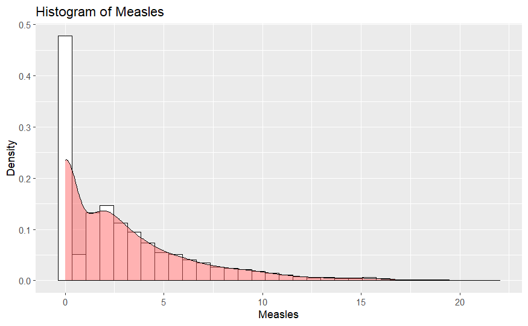

```r
ggplot(df_copy_1, aes(x=Measles)) +
  geom_histogram(aes(y=..density..), binwidth=0.7, color="black", fill="white") +
  geom_density(alpha=0.5, fill="#FF6666") +
  labs(title="Histogram of Measles", x="Measles", y="Density")
```

```r
Percentage_expe_sqrt <- sqrt(sqrt(df_copy_1$percentage.expenditure))
skewness(Percentage_expe_sqrt)
```

```
[1] 0.7289899
```

```r
df_copy_1$percentage.expenditure <- Percentage_expe_sqrt
```

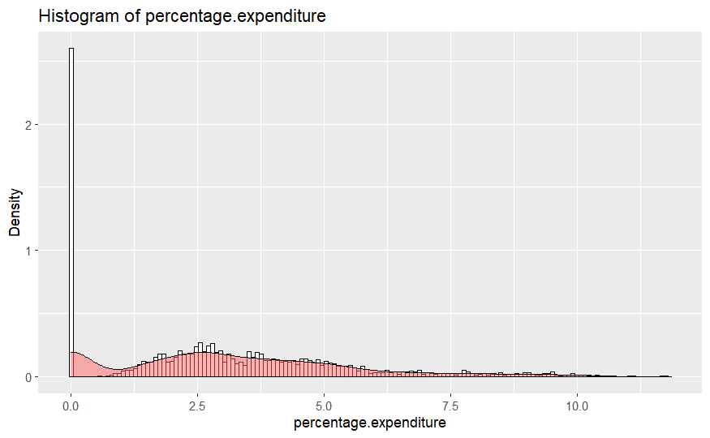

```r
ggplot(df_copy_1, aes(x=percentage.expenditure)) +
  geom_histogram(aes(y=..density..), binwidth=0.08, color="black", fill="white") +
  geom_density(alpha=0.5, fill="#FF6666") +
  labs(title="Histogram of percentage.expenditure", x="percentage.expenditure", y="Density")
```

```r
infant.deaths_sqrt <- sqrt(sqrt(df_copy_1$infant.deaths))
skewness(infant.deaths_sqrt)
```

```
[1] 0.6797275
```

```r
df_copy_1$infant.deaths <- infant.deaths_sqrt
```

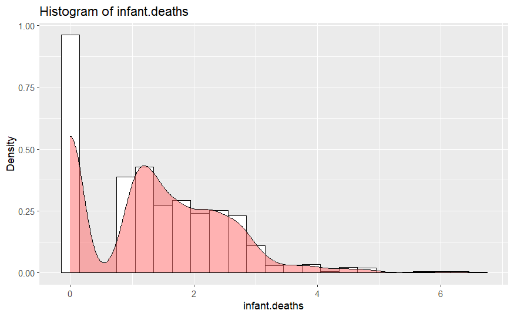

```r
ggplot(df_copy_1, aes(x=infant.deaths)) +
  geom_histogram(aes(y=..density..), binwidth=0.3, color="black", fill="white") +
  geom_density(alpha=0.5, fill="#FF6666") +
  labs(title="Histogram of infant.deaths", x="infant.deaths", y="Density")
```

```r
under.five.deaths_sqrt <- sqrt(sqrt(df_copy_1$under.five.deaths))
skewness(under.five.deaths_sqrt)
```

```
[1] 0.7276725
```

```r
df_copy_1$under.five.deaths <- under.five.deaths_sqrt
```

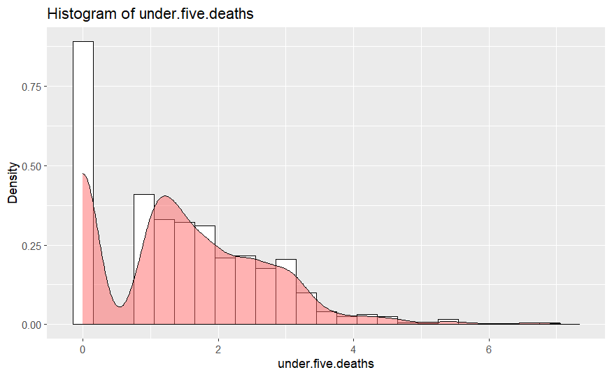

```r
ggplot(df_copy_1, aes(x=under.five.deaths)) +
  geom_histogram(aes(y=..density..), binwidth=0.3, color="black", fill="white") +
  geom_density(alpha=0.5, fill="#FF6666") +
  labs(title="Histogram of under.five.deaths", x="under.five.deaths", y="Density")
```

```r
Polio_sqrt <- sqrt(sqrt(df_copy_1$Polio ))
skewness(Polio_sqrt)
```

```
[1] -2.957654
```

```r
df_copy_1$Polio  <- Polio_sqrt
```

```r
Population_sqrt <- sqrt(sqrt(df_copy_1$Population))
skewness(Population_sqrt)
```

```
[1] 1.192727
```

```r
df_copy_1$Population  <- Population_sqrt
```

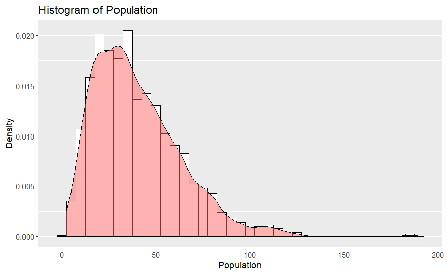

```r
ggplot(df_copy_1, aes(x=Population)) +
  geom_histogram(aes(y=..density..), binwidth=5, color="black", fill="white") +
  geom_density(alpha=0.5, fill="#FF6666") +
  labs(title="Histogram of Population", x="Population", y="Density")
```

```r
HIV.AIDS_sqrt <- sqrt(sqrt(df_copy_1$HIV.AIDS))
skewness(HIV.AIDS_sqrt)
```

```
[1] 1.884533
```

```r
df_copy_1$HIV.AIDS  <- HIV.AIDS_sqrt
```

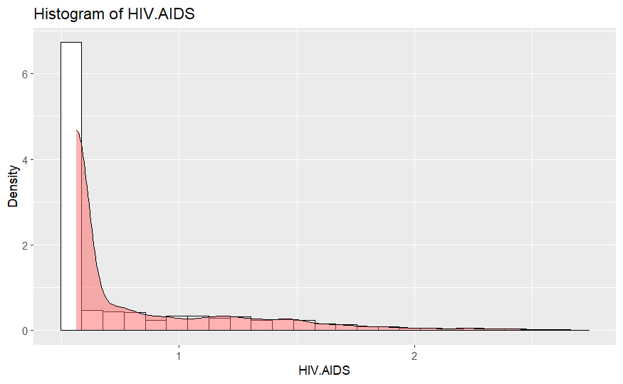

```r
ggplot(df_copy_1, aes(x=HIV.AIDS)) +
  geom_histogram(aes(y=..density..), binwidth=0.09, color="black", fill="white") +
  geom_density(alpha=0.5, fill="#FF6666") +
  labs(title="Histogram of HIV.AIDS", x="HIV.AIDS", y="Density")
```

```r
GDP_sqrt <- sqrt(sqrt(df_copy_1$GDP))
skewness(GDP_sqrt)
```

```
[1] 0.7475398
```

```r
df_copy_1$GDP  <- GDP_sqrt
```

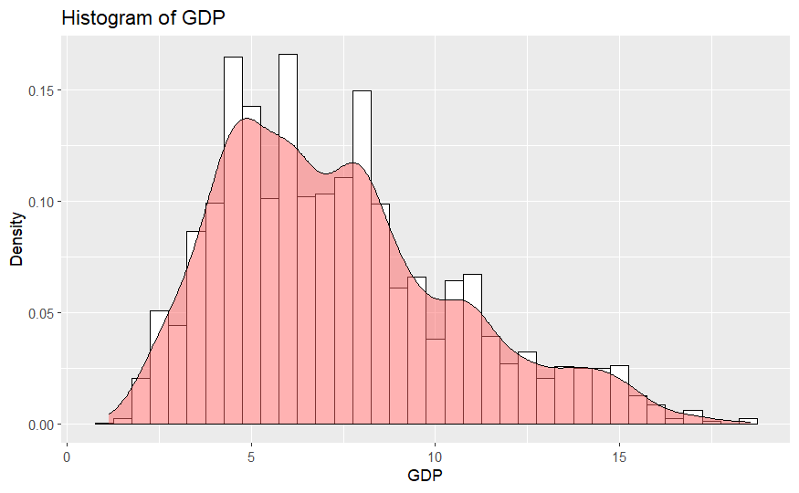

```r
ggplot(df_copy_1, aes(x=GDP)) +
  geom_histogram(aes(y=..density..), binwidth=0.5, color="black", fill="white") +
  geom_density(alpha=0.5, fill="#FF6666") +
  labs(title="Histogram of GDP", x="GDP", y="Density")
```

**Skewness of the Datasets after Normalizing**

```r
skewness_1 <- function(x) {
  n <- length(x)
  m3 <- sum((x - mean(x))^3)/(n-1)
  s3 <- sd(x)^3
  skewness <- m3/s3
  return(skewness)
}

for (col in names(df_copy_1)) {
  if(is.numeric(df_copy_1[[col]])){
    print(paste(col, "is:", skewness_1(df_copy_1[[col]])))
  }
}
```

```
[1] "Life.expectancy is: -0.635856669158128"
[1] "Adult.Mortality is: 1.17172589519657"
[1] "infant.deaths is: 0.679958962571999"
[1] "Alcohol is: 0.609030000411964"
[1] "percentage.expenditure is: 0.729238115659287"
[1] "Hepatitis.B is: -1.58984428227641"
[1] "Measles is: 1.65910196085473"
[1] "BMI is: -0.217067070312807"
[1] "under.five.deaths is: 0.727920277782387"
[1] "Polio is: -2.95866101548017"
[1] "Total.expenditure is: 0.619390409871752"
[1] "Diphtheria is: -2.06115278591113"
[1] "HIV.AIDS is: 1.88517466390931"
[1] "GDP is: 0.747794352536623"
[1] "Population is: 1.19313265642152"
[1] "thinness..1.19.years is: 1.67634269718188"
[1] "thinness.5.9.years is: 1.7384013998031"
[1] "Income.composition.of.resources is: -1.16698627027287"
[1] "Schooling is: -0.616449433074087"
```

**Feature Selection**

**Correlation Method**

```r
correlations <- cor(df_copy_1)
sorted_correlations <- sort(correlations['Life.expectancy',], decreasing=TRUE)

for (i in 1:length(sorted_correlations)) {
  print(paste(names(sorted_correlations)[i], ':', sorted_correlations[i]))
}
```

```
[1] "Life.expectancy : 1"
[1] "Schooling : 0.704294298045188"
[1] "Income.composition.of.resources : 0.690883034766278"
[1] "BMI : 0.556433178433153"
[1] "GDP : 0.54457339936761"
[1] "Diphtheria : 0.474084429604973"
[1] "percentage.expenditure : 0.423768265757413"
[1] "Alcohol : 0.400318941908566"
[1] "Polio : 0.358585307880295"
[1] "Hepatitis.B : 0.248073596079946"
[1] "Total.expenditure : 0.210744089883623"
[1] "Population : -0.014133660075424"
[1] "Measles : -0.315516631175639"
[1] "thinness.5.9.years : -0.472484735902466"
[1] "thinness..1.19.years : -0.476808562984325"
[1] "infant.deaths : -0.55954857333208"
[1] "under.five.deaths : -0.58507078777411"
[1] "Adult.Mortality : -0.695730283490939"
[1] "HIV.AIDS : -0.786991201010715"
```

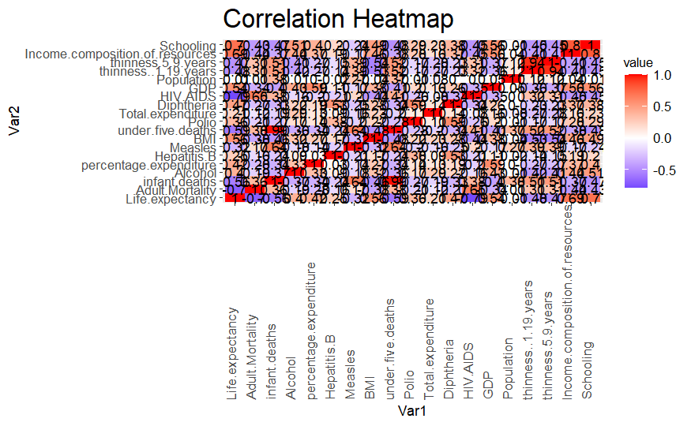

```r
library(ggplot2)

ggplot(data = reshape2::melt(cor(df_copy_1)), aes(x = Var1, y = Var2, fill = value)) +
  geom_tile(aes(fill=value)) +
  scale_fill_gradient2(low = "blue", high = "red", mid = "white", midpoint = 0) +
  geom_text(aes(label=round(value, 2)), color="black") +

  theme(axis.text.x = element_text(angle = 90, vjust = 0.01, hjust=0.01)) +
  labs(title="Correlation Heatmap") +
  theme(plot.title = element_text(size=20),
        axis.text.y = element_text(size= 10),
        axis.text.x = element_text(size= 10),
        legend.text = element_text(size= 10),
        legend.title = element_text(size=10))
```

```r
data_n = df_copy_1
trainIndex <- sample(nrow(data_n), floor(0.75 * nrow(data_n)), replace = FALSE)
train <- data_n[trainIndex, ]
train
```

|  | Life.expectancy | Adult.Mortality | infant.deaths | Alcohol | percentage.expenditure | Hepatitis.B | Measles | BMI | under.five.deaths | Polio | Total.expenditure | Diphtheria | HIV.AIDS | GDP | Population | thinness..1.19.years | thinness.5.9.years | Income.composition.of.resources | Schooling |
| --- | --- | --- | --- | --- | --- | --- | --- | --- | --- | --- | --- | --- | --- | --- | --- | --- | --- | --- | --- |
| 2915 | 52.60 | 487.0 | 2.378414 | 2.080 | 1.8149818 | 8.00000 | 4.809373 | 19.20000 | 2.672345 | 2.962257 | 4.370000 | 8.00000 | 1.9203692 | 3.271785 | 59.727283 | 6.900000 | 6.800000 | 0.4920000 | 11.100000 |
| 124 | 86.00 | 69.0 | 1.000000 | 9.840 | 4.9254876 | 95.00000 | 2.892508 | 6.90000 | 1.000000 | 3.097041 | 8.570000 | 92.00000 | 0.5623413 | 7.676386 | 12.077090 | 0.700000 | 0.600000 | 0.9080000 | 20.700000 |
| 1768 | 54.80 | 48.0 | 2.828427 | 1.190 | 2.6579488 | 76.00000 | 3.470100 | 21.30000 | 3.080070 | 2.923013 | 5.580000 | 76.00000 | 1.6207360 | 4.878683 | 40.029912 | 3.600000 | 3.500000 | 0.4000000 | 9.200000 |
| 845 | 54.40 | 337.0 | 1.316074 | 7.190 | 1.8637701 | 57.80000 | 0.000000 | 2.20000 | 1.414214 | 1.495349 | 1.630000 | 39.00000 | 1.4878153 | 3.691170 | 29.499824 | 9.800000 | 9.800000 | 0.5630000 | 8.700000 |
| 2703 | 65.80 | 211.0 | 1.626577 | 2.480 | 4.4305418 | 96.00000 | 0.000000 | 44.20000 | 1.681793 | 3.130169 | 1.990000 | 96.00000 | 0.5623413 | 8.162570 | 15.566765 | 3.200000 | 3.300000 | 0.0000000 | 10.600000 |
| 1131 | 61.80 | 266.0 | 2.030543 | 6.080 | 2.7450240 | 80.42857 | 0.000000 | 4.70000 | 2.189939 | 2.806066 | 5.560000 | 63.00000 | 1.2818610 | 4.981538 | 55.600556 | 4.200000 | 4.200000 | 0.4580000 | 8.400000 |
| 1052 | 71.70 | 167.0 | 0.000000 | 9.060 | 5.0729219 | 91.00000 | 0.000000 | 41.10000 | 0.000000 | 3.088591 | 5.990000 | 91.00000 | 0.5623413 | 9.069065 | 55.616573 | 3.900000 | 3.900000 | 0.0000000 | 15.100000 |
| 1134 | 58.70 | 32.0 | 2.059767 | 6.100 | 2.8328201 | 86.64286 | 0.000000 | 37.50000 | 2.213364 | 2.759669 | 5.610000 | 55.00000 | 1.4400153 | 4.438048 | 54.952686 | 4.500000 | 4.500000 | 0.4500000 | 8.100000 |
| 771 | 73.90 | 152.0 | 1.565085 | 2.965 | 0.0000000 | 81.00000 | 0.000000 | 58.90000 | 1.626577 | 3.054076 | 4.980000 | 85.00000 | 0.7400828 | 8.968100 | 35.160807 | 3.300000 | 3.200000 | 0.7180000 | 13.200000 |
| 1453 | 76.00 | 216.0 | 0.000000 | 9.920 | 3.0534221 | 99.00000 | 1.189207 | 57.00000 | 0.000000 | 3.154342 | 6.370000 | 99.00000 | 0.5623413 | 9.324217 | 38.681542 | 2.500000 | 2.500000 | 0.7910000 | 15.900000 |

[output cut: 990 more lines]

```r
test <- data_n[-trainIndex, ]
# Feature selection using Lasso regression
x_1 <- as.matrix(train[,2:ncol(train)])
y_1 <- train[,1]

lassoModel <- cv.glmnet(x_1, y_1, alpha = 0.5)
coef(lassoModel)
```

```
19 x 1 sparse Matrix of class "dgCMatrix"
                                          s1
(Intercept)                     65.808456827
Adult.Mortality                 -0.012814688
infant.deaths                    .
Alcohol                          0.082674418
percentage.expenditure           0.233564199
Hepatitis.B                      .
Measles                          .
BMI                              0.013396145
under.five.deaths               -0.937336375
Polio                            0.126472664
Total.expenditure                0.059211576
Diphtheria                       0.030325391
HIV.AIDS                        -8.829941192
GDP                              0.097495520
Population                       .
thinness..1.19.years            -0.000283757
thinness.5.9.years              -0.021850339
Income.composition.of.resources  6.418558508
Schooling                        0.378772575
```

**Anova Feature Slection score method**

```r
X <- df_copy_1[, -1]
y <- df_copy_1[, 1]


fs <- apply(X, 2, function(x) summary(aov(y ~ x))[[1]][1, 4])

features_map <- data.frame(feature = names(fs), score = fs)
features_map <- features_map[order(features_map$score, decreasing = TRUE), ]

print("The feature scores generated using ANOVA method are: ")
```

```
[1] "The feature scores generated using ANOVA method are: "
```

```r
for (i in 1:nrow(features_map)) {
  print(paste0("Feature ", i, ": ", features_map$feature[i], " - ", features_map$score[i]))
}
```

```
[1] "Feature 1: HIV.AIDS - 4777.22665632284"
[1] "Feature 2: Schooling - 2889.74889319136"
[1] "Feature 3: Adult.Mortality - 2754.37051311568"
[1] "Feature 4: Income.composition.of.resources - 2681.19684779012"
[1] "Feature 5: under.five.deaths - 1528.09447948579"
[1] "Feature 6: infant.deaths - 1338.24216681776"
[1] "Feature 7: BMI - 1316.71733393934"
[1] "Feature 8: GDP - 1237.7757047412"
[1] "Feature 9: thinness..1.19.years - 863.891726115104"
[1] "Feature 10: Diphtheria - 851.194967910277"
[1] "Feature 11: thinness.5.9.years - 843.812169338012"
[1] "Feature 12: percentage.expenditure - 642.652842179943"
[1] "Feature 13: Alcohol - 560.300534606921"
[1] "Feature 14: Polio - 433.226702343313"
[1] "Feature 15: Measles - 324.594622322818"
[1] "Feature 16: Hepatitis.B - 192.531415987745"
[1] "Feature 17: Total.expenditure - 136.457263899143"
[1] "Feature 18: Population - 0.586613561295334"
```

**Finalizing the Data set and Reduce the Data sets with the Potential Predictors**

```r
final_df =df_copy_1[,c( "Life.expectancy","Schooling","HIV.AIDS","Adult.Mortality","infant.deaths","Alcohol",
                       "Measles","Total.expenditure","BMI","GDP","Income.composition.of.resources")]
poly_df = final_df
head(final_df)
```

|  | Life.expectancy | Schooling | HIV.AIDS | Adult.Mortality | infant.deaths | Alcohol | Measles | Total.expenditure | BMI | GDP | Income.composition.of.resources |
| --- | --- | --- | --- | --- | --- | --- | --- | --- | --- | --- | --- |
| 1 | 65.0 | 10.1 | 0.5623413 | 263 | 2.806066 | 0.01 | 5.828428 | 8.16 | 19.1 | 4.916447 | 0.479 |
| 2 | 59.9 | 10.0 | 0.5623413 | 271 | 2.828427 | 0.01 | 4.709679 | 8.18 | 18.6 | 4.975209 | 0.476 |
| 3 | 59.9 | 9.9 | 0.5623413 | 268 | 2.850270 | 0.01 | 4.553728 | 8.13 | 18.1 | 5.013436 | 0.470 |
| 4 | 59.5 | 9.8 | 0.5623413 | 272 | 2.882121 | 0.01 | 7.265813 | 8.52 | 17.6 | 5.087589 | 0.463 |
| 5 | 59.2 | 9.5 | 0.5623413 | 275 | 2.902783 | 0.01 | 7.408833 | 7.87 | 17.2 | 2.823300 | 0.454 |
| 6 | 58.8 | 9.2 | 0.5623413 | 279 | 2.932972 | 0.01 | 6.678189 | 9.20 | 16.7 | 4.850046 | 0.448 |

```r
sum(is.na(final_df))
```

```
[1] 0
```

```r
str(final_df)
```

```
'data.frame':   2938 obs. of  11 variables:
 $ Life.expectancy                : num  65 59.9 59.9 59.5 59.2 58.8 58.6 58.1 57.5 57.3 ...
 $ Schooling                      : num  10.1 10 9.9 9.8 9.5 9.2 8.9 8.7 8.4 8.1 ...
 $ HIV.AIDS                       : num  0.562 0.562 0.562 0.562 0.562 ...
 $ Adult.Mortality                : num  263 271 268 272 275 279 281 287 295 295 ...
 $ infant.deaths                  : num  2.81 2.83 2.85 2.88 2.9 ...
 $ Alcohol                        : num  0.01 0.01 0.01 0.01 0.01 0.01 0.01 0.03 0.02 0.03 ...
 $ Measles                        : num  5.83 4.71 4.55 7.27 7.41 ...
 $ Total.expenditure              : num  8.16 8.18 8.13 8.52 7.87 9.2 9.42 8.33 6.73 7.43 ...
 $ BMI                            : num  19.1 18.6 18.1 17.6 17.2 16.7 16.2 15.7 15.2 14.7 ...
 $ GDP                            : num  4.92 4.98 5.01 5.09 2.82 ...
 $ Income.composition.of.resources: num  0.479 0.476 0.47 0.463 0.454 0.448 0.434 0.433 0.415 0.405 ...
```

**Spliiting The Dataset into Traing and Testing set**

```r
trainIndex <- sample(seq_len(nrow(final_df)), floor(0.78 * nrow(final_df)))
train <- final_df[trainIndex, ]
test <- final_df[-trainIndex, ]

# fit linear regression model
lm.fit <- lm(Life.expectancy ~ ., data = train)

train[,-1]
```

|  | Schooling | HIV.AIDS | Adult.Mortality | infant.deaths | Alcohol | Measles | Total.expenditure | BMI | GDP | Income.composition.of.resources |
| --- | --- | --- | --- | --- | --- | --- | --- | --- | --- | --- |
| 2273 | 13.500000 | 0.5623413 | 132.0 | 1.000000 | 9.540 | 1.189207 | 1.500000 | 55.800000 | 5.091031 | 0.7490000 |
| 885 | 8.400000 | 0.9740037 | 237.0 | 3.470100 | 1.860 | 8.513377 | 5.190000 | 16.800000 | 2.687330 | 0.4270000 |
| 1264 | 16.500000 | 0.5623413 | 88.0 | 0.000000 | 14.170 | 3.948222 | 6.850000 | 52.900000 | 13.430794 | 0.8620000 |
| 188 | 13.900000 | 0.5623413 | 83.0 | 0.000000 | 2.160 | 1.821160 | 3.370000 | 55.600000 | 11.219750 | 0.8030000 |
| 2219 | 11.100000 | 0.6687403 | 191.0 | 0.000000 | 0.010 | 0.000000 | 8.350000 | 3.100000 | 6.533259 | 0.5620000 |
| 174 | 12.100000 | 0.5623413 | 19.0 | 0.000000 | 10.850 | 0.000000 | 5.260000 | 56.000000 | 11.709642 | 0.7810000 |
| 1015 | 10.900000 | 1.0677900 | 263.0 | 2.514867 | 1.640 | 3.309751 | 4.810000 | 26.100000 | 6.299683 | 0.5540000 |
| 888 | 8.100000 | 1.1418583 | 261.0 | 3.567621 | 1.340 | 8.067024 | 6.860000 | 15.600000 | 4.298489 | 0.4010000 |
| 1881 | 5.100000 | 0.9146912 | 232.0 | 2.645751 | 0.010 | 4.061086 | 6.110000 | 18.100000 | 4.448230 | 0.3310000 |
| 1057 | 14.300000 | 0.5623413 | 178.0 | 0.000000 | 9.610 | 0.000000 | 7.670000 | 38.200000 | 4.775207 | 0.0000000 |

[output cut: 990 more lines]

```r
str(train[,-1])
```

```
'data.frame':   2291 obs. of  10 variables:
 $ Schooling                      : num  13.5 8.4 16.5 13.9 11.1 12.1 10.9 8.1 5.1 14.3 ...
 $ HIV.AIDS                       : num  0.562 0.974 0.562 0.562 0.669 ...
 $ Adult.Mortality                : num  132 237 88 83 191 19 263 261 232 178 ...
 $ infant.deaths                  : num  1 3.47 0 0 0 ...
 $ Alcohol                        : num  9.54 1.86 14.17 2.16 0.01 ...
 $ Measles                        : num  1.19 8.51 3.95 1.82 0 ...
 $ Total.expenditure              : num  1.5 5.19 6.85 3.37 8.35 5.26 4.81 6.86 6.11 7.67 ...
 $ BMI                            : num  55.8 16.8 52.9 55.6 3.1 56 26.1 15.6 18.1 38.2 ...
 $ GDP                            : num  5.09 2.69 13.43 11.22 6.53 ...
 $ Income.composition.of.resources: num  0.749 0.427 0.862 0.803 0.562 0.781 0.554 0.401 0.331 0 ...
```

```r
sum(is.na(train))
```

```
[1] 0
```

```r
# fit polynomial regression model

summary(lm.fit)
```

```
Call:
lm(formula = Life.expectancy ~ ., data = train)

Residuals:
     Min       1Q   Median       3Q      Max
-19.1159  -1.9382   0.0397   2.2166  15.0879

Coefficients:
                                  Estimate Std. Error t value Pr(>|t|)
(Intercept)                     67.2125383  0.5509402 121.996  < 2e-16 ***
Schooling                        0.4371944  0.0435650  10.035  < 2e-16 ***
HIV.AIDS                        -9.6886793  0.2671545 -36.266  < 2e-16 ***
Adult.Mortality                 -0.0142390  0.0008612 -16.534  < 2e-16 ***
infant.deaths                   -0.8687122  0.1055072  -8.234 3.02e-16 ***
Alcohol                          0.1190488  0.0244746   4.864 1.23e-06 ***
Measles                         -0.0980182  0.0302741  -3.238  0.00122 **
Total.expenditure                0.1726707  0.0347810   4.965 7.40e-07 ***
BMI                              0.0156336  0.0049469   3.160  0.00160 **
GDP                              0.1729316  0.0316670   5.461 5.25e-08 ***
Income.composition.of.resources  7.7471197  0.6601621  11.735  < 2e-16 ***
---
Signif. codes:  0 ‘***’ 0.001 ‘**’ 0.01 ‘*’ 0.05 ‘.’ 0.1 ‘ ’ 1

Residual standard error: 3.774 on 2280 degrees of freedom
Multiple R-squared:  0.844, Adjusted R-squared:  0.8433
F-statistic:  1234 on 10 and 2280 DF,  p-value: < 2.2e-16
```

**Fit the Model

```r
lm.fit
```

```
Call:
lm(formula = Life.expectancy ~ ., data = train)

Coefficients:
                    (Intercept)                        Schooling                         HIV.AIDS
                       67.21254                          0.43719                         -9.68868
                Adult.Mortality                    infant.deaths                          Alcohol
                       -0.01424                         -0.86871                          0.11905
                        Measles                Total.expenditure                              BMI
                       -0.09802                          0.17267                          0.01563
                            GDP  Income.composition.of.resources
                        0.17293                          7.74712
```

**Vif score

```r
vif(lm.fit)
```

```
                      Schooling                        HIV.AIDS                 Adult.Mortality
                       3.379136                        2.021543                        1.866333
                  infant.deaths                         Alcohol                         Measles
                       2.390350                        1.525044                        1.779920
              Total.expenditure                             BMI                             GDP
                       1.144898                        1.593015                        1.685894
Income.composition.of.resources
                       3.076215
```

**Anova Test

```r
fit.aov <- anova(lm.fit)

tab <- as.table(cbind(
  'SS' = c("SSR(x1, x2, x1:X2)" = sum(fit.aov[1:3, 2]),
         "SSR(X1)"           = fit.aov[1, 2],
         "SSR(X2|X1)"        = fit.aov[2, 2],
         "SSR(X1:X2|X1,X2)"    = fit.aov[3, 2],
         "SSE(X1,X2,X1:X2)"     = fit.aov[4, 2],
         "Total"             = sum(fit.aov[, 2])),

  'Df' = c(                    sum(fit.aov[1:3, 1]),
                               fit.aov[1, 1],
                               fit.aov[2, 1],
                               fit.aov[3, 1],
                               fit.aov[4, 1],
                               sum(fit.aov$Df)),

  'MS' = c(                    sum(fit.aov[1:3, 2]) / sum(fit.aov[1:3, 1]),
                               fit.aov[1, 3],
                               fit.aov[2, 3],
                               fit.aov[3, 3],
                               fit.aov[4, 3],
                               NA)
))

round(tab, 2)
```

[output not shown]

**Multiple Regression Plots**

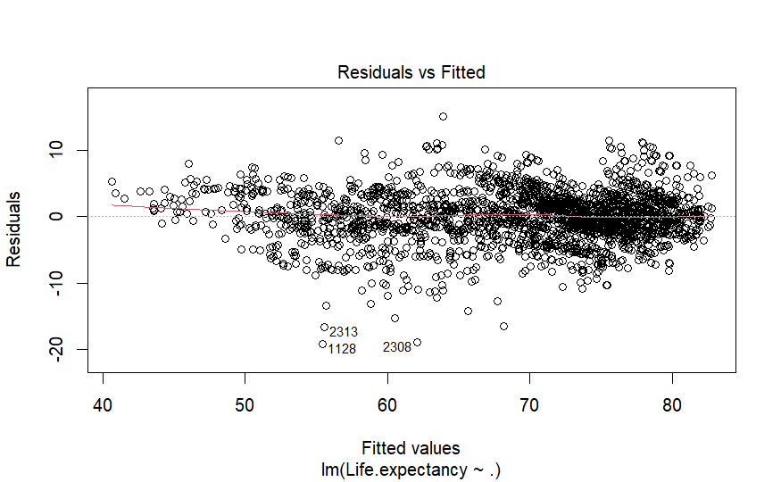

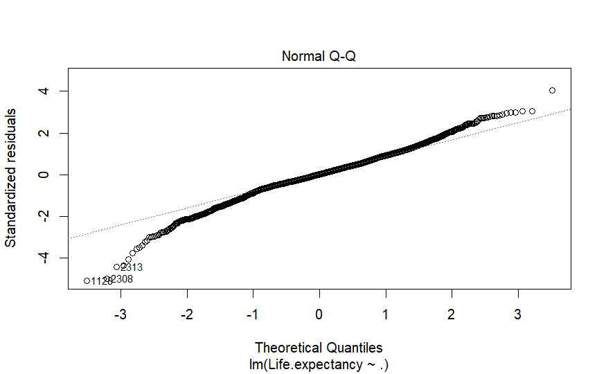

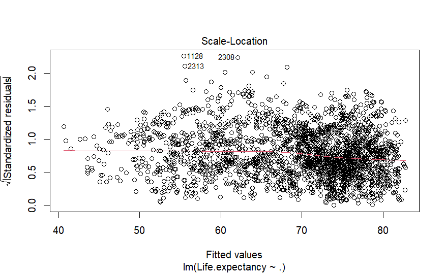

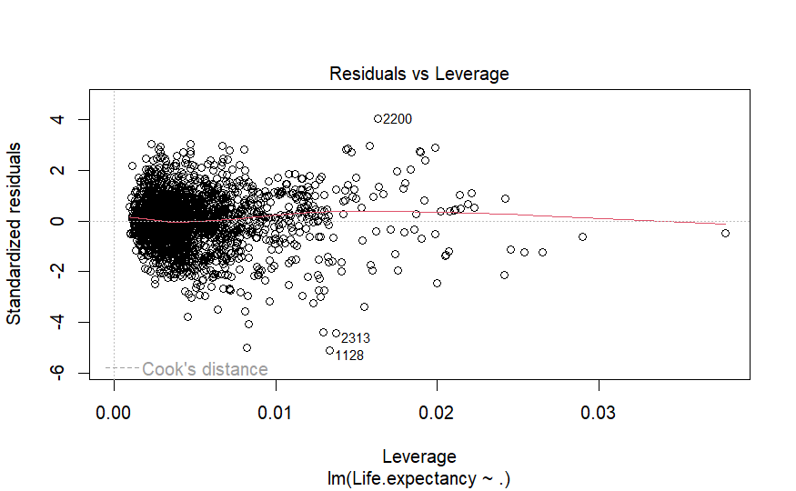

```r
plot(lm.fit)
```

**R-Squared**

```r
# calculate r-squared values for both models
lm.r_squared <- summary(lm.fit)$r.squared
print(paste0("Linear regression r-squared: ", lm.r_squared))
```

```
[1] "Linear regression r-squared: 0.843999705955735"
```

*Post processing* **Further Reducing the Model**

```r
mod_df <- subset(final_df, select = -c(Schooling, infant.deaths, Income.composition.of.resources))
head(mod_df)
```

|  | Life.expectancy | HIV.AIDS | Adult.Mortality | Alcohol | Measles | Total.expenditure | BMI | GDP |
| --- | --- | --- | --- | --- | --- | --- | --- | --- |
| 1 | 65.0 | 0.5623413 | 263 | 0.01 | 5.828428 | 8.16 | 19.1 | 4.916447 |
| 2 | 59.9 | 0.5623413 | 271 | 0.01 | 4.709679 | 8.18 | 18.6 | 4.975209 |
| 3 | 59.9 | 0.5623413 | 268 | 0.01 | 4.553728 | 8.13 | 18.1 | 5.013436 |
| 4 | 59.5 | 0.5623413 | 272 | 0.01 | 7.265813 | 8.52 | 17.6 | 5.087589 |
| 5 | 59.2 | 0.5623413 | 275 | 0.01 | 7.408833 | 7.87 | 17.2 | 2.823300 |
| 6 | 58.8 | 0.5623413 | 279 | 0.01 | 6.678189 | 9.20 | 16.7 | 4.850046 |

```r
lm.fit_mod <- lm(Life.expectancy ~ ., data = mod_df)

summary(lm.fit_mod)
```

```
Call:
lm(formula = Life.expectancy ~ ., data = mod_df)

Residuals:
     Min       1Q   Median       3Q      Max
-23.1915  -2.5818   0.1761   2.6791  14.2115

Coefficients:
                    Estimate Std. Error t value Pr(>|t|)
(Intercept)        7.376e+01  4.176e-01 176.621  < 2e-16 ***
HIV.AIDS          -1.108e+01  2.652e-01 -41.779  < 2e-16 ***
Adult.Mortality   -1.818e-02  8.631e-04 -21.062  < 2e-16 ***
Alcohol            3.427e-01  2.331e-02  14.702  < 2e-16 ***
Measles           -2.267e-01  2.469e-02  -9.184  < 2e-16 ***
Total.expenditure  1.470e-01  3.486e-02   4.216 2.56e-05 ***
BMI                4.895e-02  4.930e-03   9.931  < 2e-16 ***
GDP                5.143e-01  2.954e-02  17.413  < 2e-16 ***
---
Signif. codes:  0 ‘***’ 0.001 ‘**’ 0.01 ‘*’ 0.05 ‘.’ 0.1 ‘ ’ 1

Residual standard error: 4.349 on 2930 degrees of freedom
Multiple R-squared:  0.7914,    Adjusted R-squared:  0.7909
F-statistic:  1588 on 7 and 2930 DF,  p-value: < 2.2e-16
```

```r
lm.r_squared <- summary(lm.fit)$r.squared
print(paste0("Linear regression r-squared: ", lm.r_squared))
```

[output not shown]

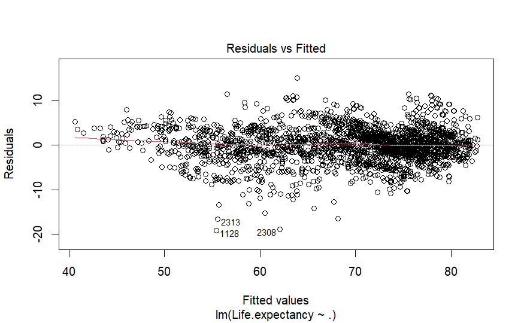

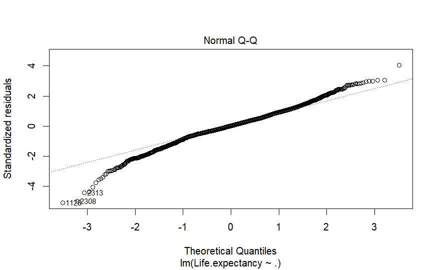

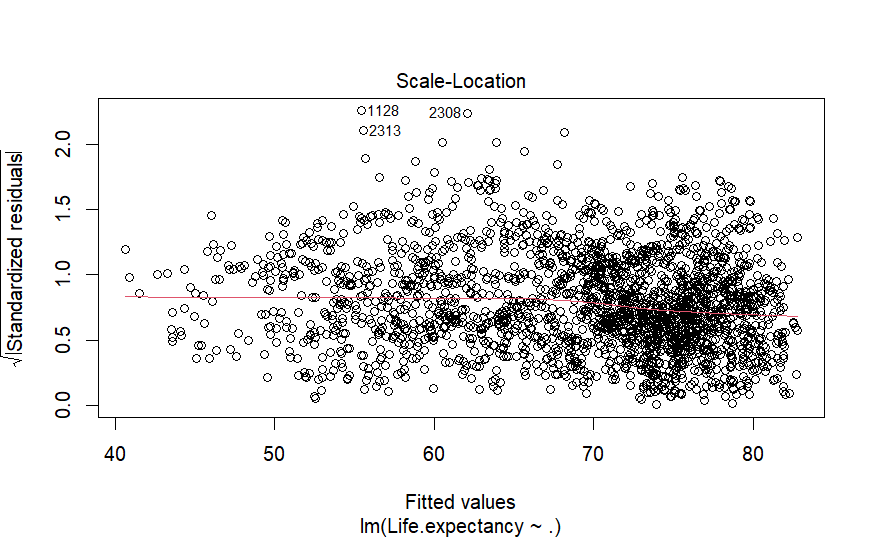

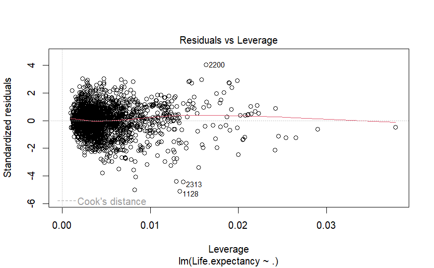

```r
plot(lm.fit)
```

```r
poly_reg = lm(formula = Life.expectancy ~ Schooling + Schooling^2 + Schooling^3 + HIV.AIDS + HIV.AIDS^2 + HIV.AIDS^3 + Adult.Mortality + Adult.Mortality^2 + Adult.Mortality^3 + infant.deaths + infant.deaths^2 + infant.deaths^3 + Alcohol + Alcohol^2 + Alcohol^3 + Measles + Measles^2 + Measles^3 + Total.expenditure + Total.expenditure^2 + Total.expenditure^3 + BMI + BMI^2 +BMI^3 + GDP + GDP^2 + GDP^3 + Income.composition.of.resources + Income.composition.of.resources^2 + Income.composition.of.resources^3,data = poly_df)

summary(poly_reg)
```

```
Call:
lm(formula = Life.expectancy ~ Schooling + Schooling^2 + Schooling^3 +
    HIV.AIDS + HIV.AIDS^2 + HIV.AIDS^3 + Adult.Mortality + Adult.Mortality^2 +
    Adult.Mortality^3 + infant.deaths + infant.deaths^2 + infant.deaths^3 +
    Alcohol + Alcohol^2 + Alcohol^3 + Measles + Measles^2 + Measles^3 +
    Total.expenditure + Total.expenditure^2 + Total.expenditure^3 +
    BMI + BMI^2 + BMI^3 + GDP + GDP^2 + GDP^3 + Income.composition.of.resources +
    Income.composition.of.resources^2 + Income.composition.of.resources^3,
    data = poly_df)

Residuals:
     Min       1Q   Median       3Q      Max
-20.0988  -1.9763   0.0518   2.2318  14.9758

Coefficients:
                                  Estimate Std. Error t value Pr(>|t|)
(Intercept)                     67.5842926  0.4867453 138.849  < 2e-16 ***
Schooling                        0.4169463  0.0389141  10.715  < 2e-16 ***
HIV.AIDS                        -9.6659788  0.2371008 -40.767  < 2e-16 ***
Adult.Mortality                 -0.0144805  0.0007674 -18.870  < 2e-16 ***
infant.deaths                   -0.9453013  0.0942088 -10.034  < 2e-16 ***
Alcohol                          0.1233136  0.0218041   5.656 1.70e-08 ***
Measles                         -0.0668474  0.0268716  -2.488   0.0129 *
Total.expenditure                0.1352579  0.0306180   4.418 1.03e-05 ***
BMI                              0.0177496  0.0044492   3.989 6.79e-05 ***
GDP                              0.1895129  0.0280834   6.748 1.80e-11 ***
Income.composition.of.resources  7.6730577  0.5933148  12.933  < 2e-16 ***
---
Signif. codes:  0 ‘***’ 0.001 ‘**’ 0.01 ‘*’ 0.05 ‘.’ 0.1 ‘ ’ 1

Residual standard error: 3.809 on 2927 degrees of freedom
Multiple R-squared:  0.8401,    Adjusted R-squared:  0.8396
F-statistic:  1538 on 10 and 2927 DF,  p-value: < 2.2e-16
```

```r
Poly.r_squared <- summary(poly_reg)$r.squared
print(paste0("Linear regression r-squared: ", Poly.r_squared))
```

```
[1] "Linear regression r-squared: 0.840131284586183"
```

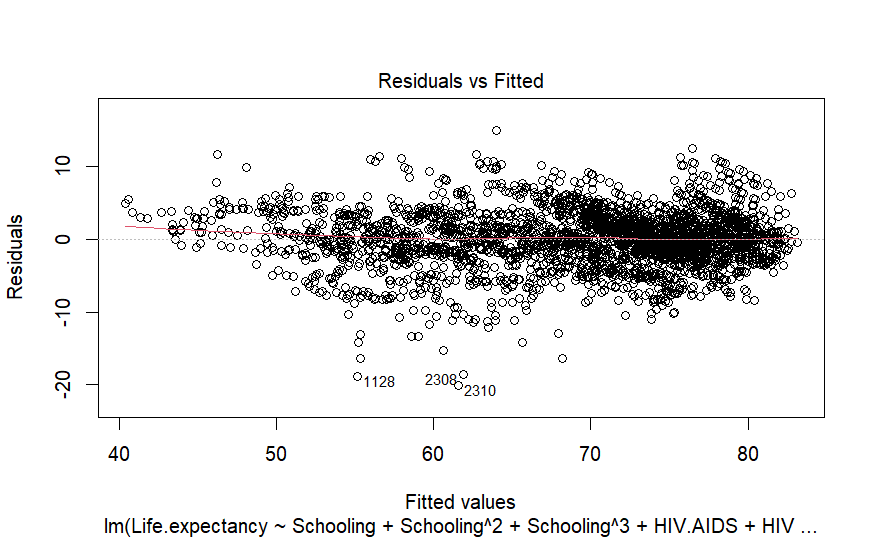

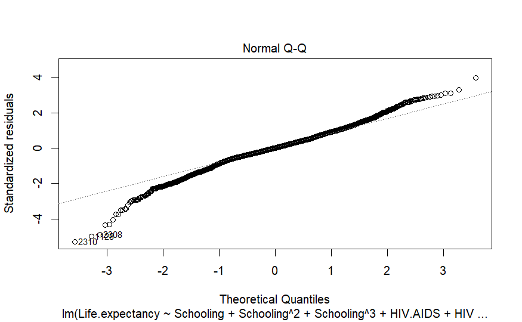

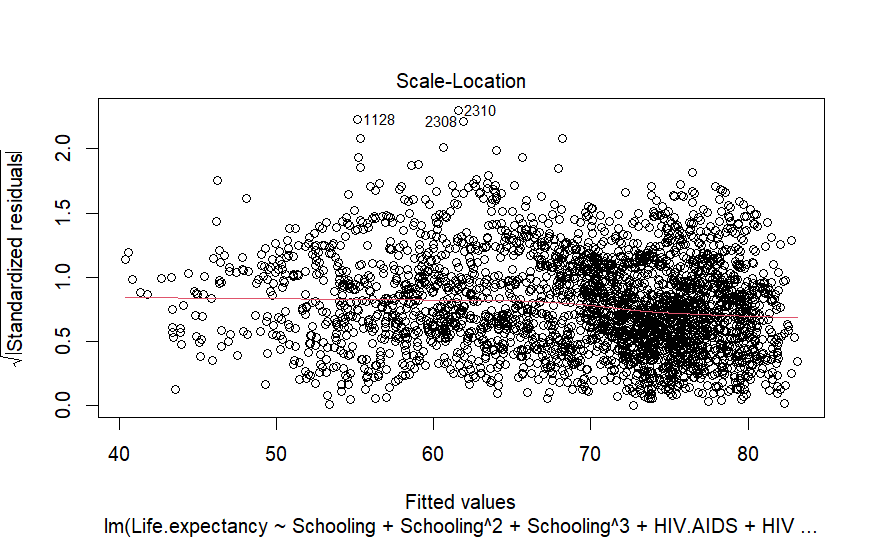

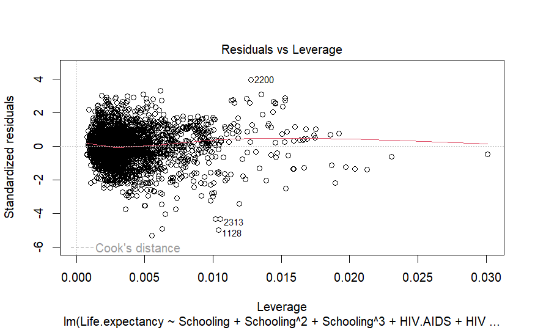

```r
plot(poly_reg)
```

```r
summary(poly_reg)
```

```
Call:
lm(formula = Life.expectancy ~ Schooling + Schooling^2 + Schooling^3 +
    HIV.AIDS + HIV.AIDS^2 + HIV.AIDS^3 + Adult.Mortality + Adult.Mortality^2 +
    Adult.Mortality^3 + infant.deaths + infant.deaths^2 + infant.deaths^3 +
    Alcohol + Alcohol^2 + Alcohol^3 + Measles + Measles^2 + Measles^3 +
    Total.expenditure + Total.expenditure^2 + Total.expenditure^3 +
    BMI + BMI^2 + BMI^3 + GDP + GDP^2 + GDP^3 + Income.composition.of.resources +
    Income.composition.of.resources^2 + Income.composition.of.resources^3,
    data = poly_df)

Residuals:
     Min       1Q   Median       3Q      Max
-20.0988  -1.9763   0.0518   2.2318  14.9758

Coefficients:
                                  Estimate Std. Error t value Pr(>|t|)
(Intercept)                     67.5842926  0.4867453 138.849  < 2e-16 ***
Schooling                        0.4169463  0.0389141  10.715  < 2e-16 ***
HIV.AIDS                        -9.6659788  0.2371008 -40.767  < 2e-16 ***
Adult.Mortality                 -0.0144805  0.0007674 -18.870  < 2e-16 ***
infant.deaths                   -0.9453013  0.0942088 -10.034  < 2e-16 ***
Alcohol                          0.1233136  0.0218041   5.656 1.70e-08 ***
Measles                         -0.0668474  0.0268716  -2.488   0.0129 *
Total.expenditure                0.1352579  0.0306180   4.418 1.03e-05 ***
BMI                              0.0177496  0.0044492   3.989 6.79e-05 ***
GDP                              0.1895129  0.0280834   6.748 1.80e-11 ***
Income.composition.of.resources  7.6730577  0.5933148  12.933  < 2e-16 ***
---
Signif. codes:  0 ‘***’ 0.001 ‘**’ 0.01 ‘*’ 0.05 ‘.’ 0.1 ‘ ’ 1

Residual standard error: 3.809 on 2927 degrees of freedom
Multiple R-squared:  0.8401,    Adjusted R-squared:  0.8396
F-statistic:  1538 on 10 and 2927 DF,  p-value: < 2.2e-16
```

```r
poly_reg
```

```
Call:
lm(formula = Life.expectancy ~ Schooling + Schooling^2 + Schooling^3 +
    HIV.AIDS + HIV.AIDS^2 + HIV.AIDS^3 + Adult.Mortality + Adult.Mortality^2 +
    Adult.Mortality^3 + infant.deaths + infant.deaths^2 + infant.deaths^3 +
    Alcohol + Alcohol^2 + Alcohol^3 + Measles + Measles^2 + Measles^3 +
    Total.expenditure + Total.expenditure^2 + Total.expenditure^3 +
    BMI + BMI^2 + BMI^3 + GDP + GDP^2 + GDP^3 + Income.composition.of.resources +
    Income.composition.of.resources^2 + Income.composition.of.resources^3,
    data = poly_df)

Coefficients:
                    (Intercept)                        Schooling                         HIV.AIDS
                       67.58429                          0.41695                         -9.66598
                Adult.Mortality                    infant.deaths                          Alcohol
                       -0.01448                         -0.94530                          0.12331
                        Measles                Total.expenditure                              BMI
                       -0.06685                          0.13526                          0.01775
                            GDP  Income.composition.of.resources
                        0.18951                          7.67306
```

**Aic Test**

```r
ply_aic = AIC(poly_reg)
ply_aic
```

```
[1] 16209.43
```

```r
lm_aic = AIC(lm.fit_mod)
lm_aic
```

```
[1] 16985.04
```

```r
print(paste0("Polynomial r-squared: ", Poly.r_squared))
```

[output not shown]

```r
print(paste0("Linear regression r-squared: ", lm.r_squared))
```

```
[1] "Linear regression r-squared: 0.843999705955735"
```

_____________________________________________**END**______________________________________________________________